# Выполнение 7 лабораторной работы

Анализ файловой структуры UNIX. Команды для работы с файлами и каталогами

Павлюченков С.В.

Российский университет дружбы народов, Москва, Россия

07 сентября 2024

## Докладчик

- Павлюченков Сергей Витальевич
- Студент ФФМиЕН
- Российский университет дружбы народов
- 1132237372@pfur.ru
- https://serapshi.github.io/svpavliuchenkov.github.io/

## Цель работы

Ознакомление с файловой системой Linux, её структурой, именами и содержанием каталогов. Приобретение практических навыков по применению команд для работы с файлами и каталогами, по управлению процессами (и работами), по проверке использования диска и обслуживанию файловой системы.

## Задание

1. Выполните все примеры, приведённые в первой части описания лабораторной работы.
2. Выполните следующие действия, зафиксировав в отчёте по лабораторной работе используемые при этом команды и результаты их выполнения: 2.1. Скопируйте файл /usr/include/sys/io.h в домашний каталог и назовите его equipment. Если файла io.h нет, то используйте любой другой файл в каталоге /usr/include/sys/ вместо него. 2.2. В домашнем каталоге создайте директорию ~/ski.plases. 2.3. Переместите файл equipment в каталог ~/ski.plases. 2.4. Переименуйте файл ~/ski.plases/equipment в ~/ski.plases/equiplist. 2.5. Создайте в домашнем каталоге файл abc1 и скопируйте его в каталог ~/ski.plases, назовите его equiplist2. 2.6. Создайте каталог с именем equipment в каталоге ~/ski.plases. 2.7. Переместите файлы ~/ski.plases/equiplist и equiplist2 в каталог ~/ski.plases/equipment. 2.8. Создайте и переместите каталог ~/newdir в каталог ~/ski.plases и назовите его plans. Кулябов Д. С. и др. Операционные системы 53

## Задание

3. Определите опции команды chmod, необходимые для того, чтобы присвоить перечисленным ниже файлам выделенные права доступа, считая, что в начале таких прав нет: 3.1. drwxr–r– … australia 3.2. drwx–x–x … play 3.3. -r-xr–r– … my_os 3.4. -rw-rw-r– … feathers При необходимости создайте нужные файлы.
4. Проделайте приведённые ниже упражнения, записывая в отчёт по лабораторной работе используемые при этом команды: 4.1. Просмотрите содержимое файла /etc/password. 4.2. Скопируйте файл ~/feathers в файл ~/file.old. 4.3. Переместите файл ~/file.old в каталог ~/play. 4.4. Скопируйте каталог ~/play в каталог ~/fun. 4.5. Переместите каталог ~/fun в каталог ~/play и назовите его games. 4.6. Лишите владельца файла ~/feathers права на чтение. 4.7. Что произойдёт, если вы попытаетесь просмотреть файл ~/feathers командой cat? 4.8. Что произойдёт, если вы попытаетесь скопировать файл ~/feathers? 4.9. Дайте владельцу файла ~/feathers право на чтение. 4.10. Лишите владельца каталога ~/play права на выполнение. 4.11. Перейдите в каталог ~/play. Что произошло? 4.12. Дайте владельцу каталога ~/play право на выполнение.
5. Прочитайте man по командам mount, fsck, mkfs, kill и кратко их охарактеризуйте, приведя примеры.

# Выполнение лабораторной работы

## Работа с командой cp

Скопировал файл ~/abc1 в файл april и в файл may:

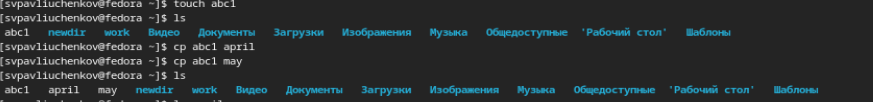

Копирование файла в текущем каталоге

## Работа с командой cp -r

Скопировал каталог monthly в каталог monthly.00:

[figure not shown]

Копирование каталогов в текущем каталоге

## Работа с командой mv

Изменил название файла april на july в домашнем каталоге

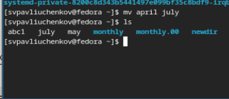

Переименование файлов в текущем каталоге

## Работа с командой cp -r

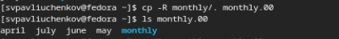

## Создание файла ~/may с правом выполнения для владельца

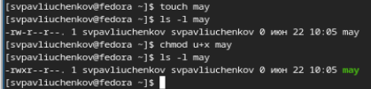

Создание файлов с правом выполнения

## Работа с командой chmod

Лишаю владельца файла ~/may права на выполнение

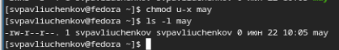

Лишение права на выполнение

## Просмотр используемых в операционной системе файловых систем командой mount

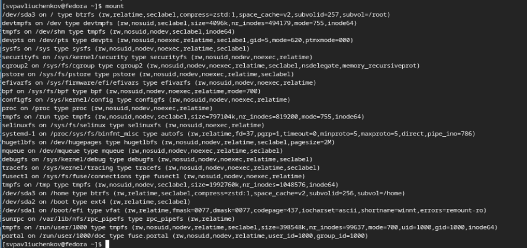

Просмотр используемых файловых систем

## Просмотр файла/etc/fstab.

Определяю смонтированные в операционной системе файловых систем

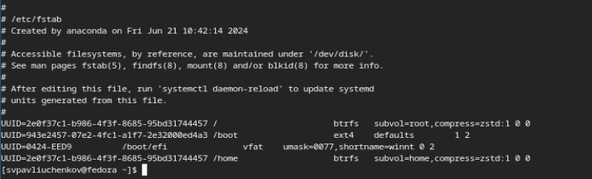

Просмотр испольщуемых файловых систем

## Работа с df

Определяю объёма свободного пространства на файловой системе

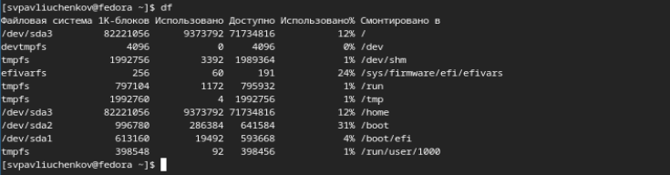

Объем свободного места

## Повторная работа с базовыми командами

Копирую файл /usr/include/sys/uio.h в домашний каталог и называю его equipment В домашнем каталоге создаю директорию ~/ski.plases. и перемещаю в каталог ~/ski.plases. Переименовываю файл ~/ski.plases/equipment в ~/ski.plases/equiplist Создаю в домашнем каталоге файл abc1 и копирую его в каталог ~/ski.plases, называю его equiplist2. Создаю каталог с именем equipment в каталоге ~/ski.plases и перемещаю файлы ~/ski.plases/equiplist и equiplist2 в каталог ~/ski.plases/equipment.

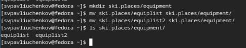

Перемещаю каталоги

## Повторная работа с базовыми командами

Создаю и перемещаю каталог ~/newdir в каталог ~/ski.plases и называю его plans.

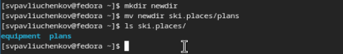

Создание нового каталога

## Работа с chmod

Определил опции команды chmod, необходимые для того, чтобы присвоить перечисленным ниже файлам выделенные права доступа для (play)=+x rw+u; (my_os)=+r g+x;(feather)=+r ug+w

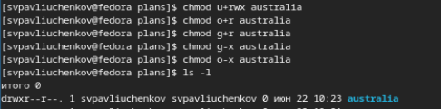

Права доступа

## Работа с cat

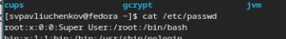

использование cat

Скопировал файл ~/feathers в файл ~/file.old Переместил файл ~/file.old в каталог ~/play.

## Работа с cat

Скопировал каталог ~/play в каталог ~/fun и переместил каталог ~/fun в каталог ~/play и назвал его games

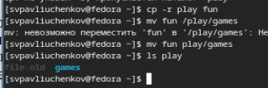

Копирование с изменением названия

## Работа с chmod

Лишил владельца файла ~/feathers права на чтение. Из-за чего Файл не считался и не открылся

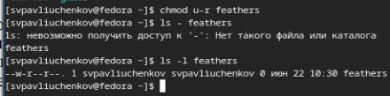

Лишение права на чтение

## Работа с chmod

Дал право на чтение

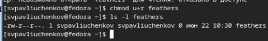

Право на чтение

## Работа с chmod

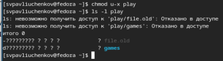

Работа с директорий без право на выполнение

## Выводы

Я научился лучше работать с файловой структорой UNIX. Значительно улучшил навык использование команд для взаимодействия с файлами и каталогами.